# HW_3/9

Larin Anton

12/18/2020

## ИДЗ 3 Статан

## ИДЗ 9 Матпакеты

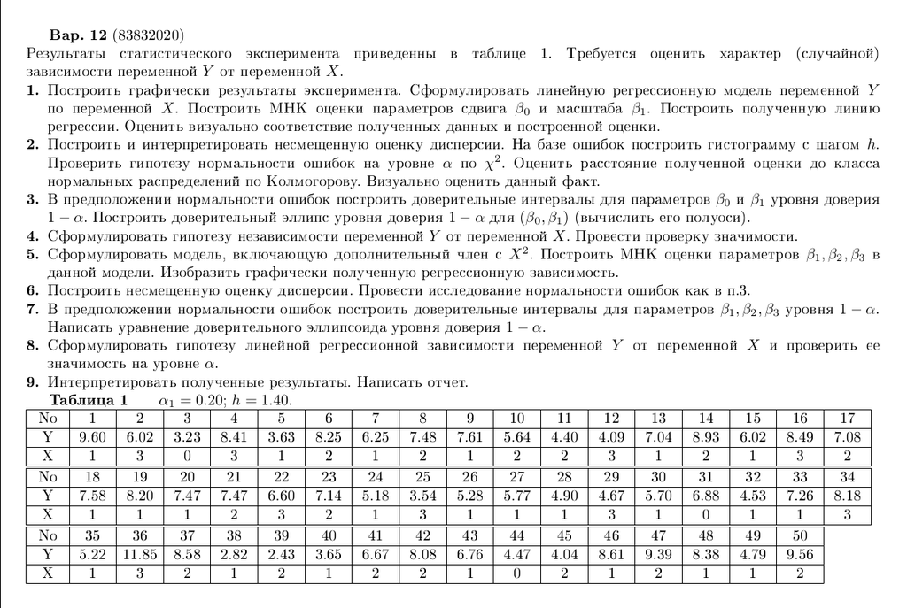

#Ход работы ##Графические представление

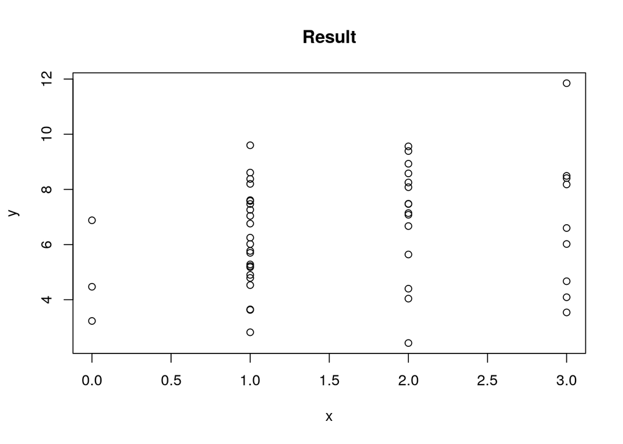

```r
plot(x,y,main="Result")
```

Линейная регрессионная модель: $y = \beta_0 + \beta_1*x$

## 1

МНК оценка параметров сдвига $\beta_0$ и масштаба $\beta_1$

```r
n<-length(y)
x0<-array(1,dim=n)
X<-t(matrix(c(x0,x),nrow=n,ncol=2))
Y<-as.matrix(y)
S<-X%*%t(X)
S1<-solve(S)
bhat<-S1%*%X%*%Y
```

#### Результат:

$\beta_0 = 5.5889333$  
$\beta_1 = 0.5546667$

Нарисуем полученную регрессионную зависимость

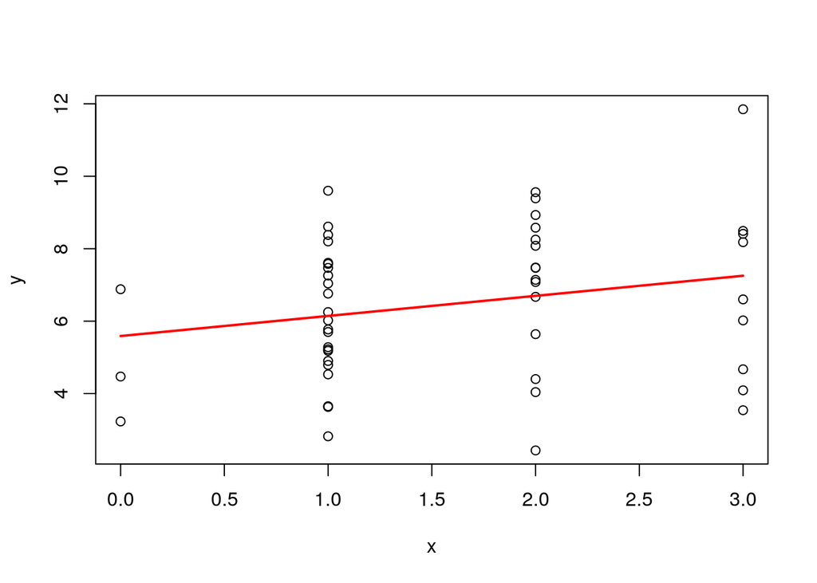

## 2

Построение несмещенной оценки дисперсии

```r
  res<-Y-t(X)%*%as.matrix(bhat)
SS<-sum(res^2)
s2<-SS/(n-2)
```

Результат: $4.0704077$

Построение гистограммы с шагом h = 1.4 на базе ошибок

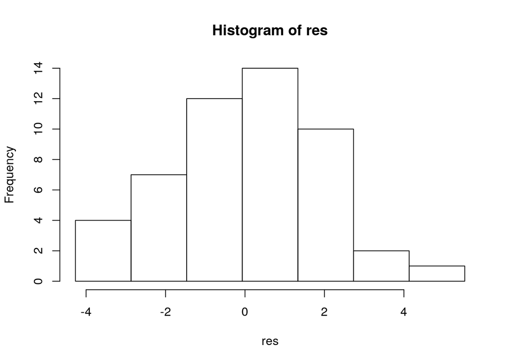

Проверка гипотезы нормальности ошибок на уровне $\alpha$ по $\chi^2$ $H_0: Y-X^T \beta\sim(0,\sigma^2)$

```r
hh<-hist(res,breaks=brk,plot=FALSE)
nu<-hh$counts
breaks = hh$breaks;
r = length(breaks) - 1
l.b<-length(brk)
csq0<-function(s){
  if (s>0){
    p<-pnorm(brk[2:l.b],0,s)-pnorm(brk[1:(l.b-1)],0,s)
    return(sum((nu-n*p)^2/n/p))
  } else {
    return(Inf)
  }
}
csq.s<-nlm(csq0,p=sqrt(s2))$minimum
pv<-pchisq(csq.s,r - 2,lower.tail=FALSE)
```

Результат: FALSE

Оценим расстояние оценки до класса нормальных распределений оп Колмогорову

```r
kolm.stat<-function(s){
  sres<-sort(res)
  fdistr<-pnorm(sres,0,s)
  max(abs(c(0:(n-1))/n-fdistr),abs(c(1:n)/n-fdistr))
}
ks.dist<-nlm(kolm.stat,p=sqrt(s2))$minimum
```

Полученое расстояние: 0.0708533

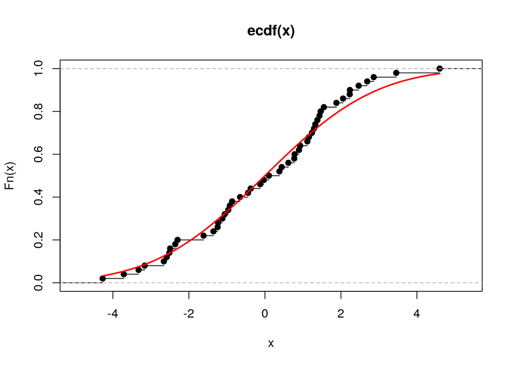

## 3

Построим ДИ для параметров с уровнем доверия $1-\alpha (0.8)$

```r
C<-diag(c(1,1))
ph<-bhat
V<-diag(S1)
xa<-qt(1-al/2,n-2)
s1<-sqrt(s2)
d<-xa*s1*sqrt(V)
CI<-data.frame(lw=ph-d,up=ph+d)
```

Для $\beta_0: [4.7975981,6.3802685]$  
Для $\beta_1: [0.1177249,0.9916084]$

Доверительный эллипс можно вычислить как

$A\alpha=\{x,y:((xy)^T-\beta)^T*(XX^T)^{-1}*((xy)^T-\beta)\le qs^2x\alpha\}$  
Где:

$\beta=$

```
##           [,1]
## [1,] 5.5889333
## [2,] 0.5546667
```

```
##             [,1]        [,2]
## [1,]  0.09111111 -0.04444444
## [2,] -0.04444444  0.02777778
```

## 4

Гипотеза независимости Y от X: $H0: \beta1=0$  
Критерий:  
$\Phi(x)=\begin{cases} 0, \alpha<PV \\ 1,\alpha>PV \end{cases}$

Найдем статистику F-критерия и P-значение:

```r
FST<-bhat[2]^2/V[2]/s2
pv.f<-pf(FST,1,n-2,lower.tail=FALSE)
```

Получим 2.7210012 и 0.1055659  
Результат: FALSE

## 5

Добавим в модель член с $X^2$:  
$Y=\beta_1+\beta_2x+\beta_3x^2+\varepsilon$

Найдем МНК оценки

```r
x0 <- array(1, dim=n)
X <- t(matrix(c(x0, x, x^2), nrow=n, ncol=3))
Y <- as.matrix(y)
S <- X%*%t(X)
S1 <- solve(S)
bht <- S1%*%X%*%Y
```

$\beta1=4.7528712$  
$\beta2=1.8515702$  
$\beta3=-0.3777389$

Нарисуем полученную регрессионную зависимость

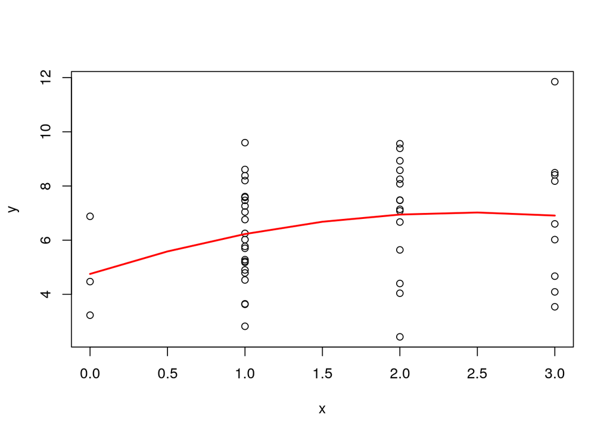

## 6

Несмещенная оценка дисперсии

```r
res<-Y-t(X)%*%as.matrix(bht)
SS<-sum(res^2)
s2<-SS/(n-2)
```

Результат: 3.9820608

Гистограмма на базе ошибок

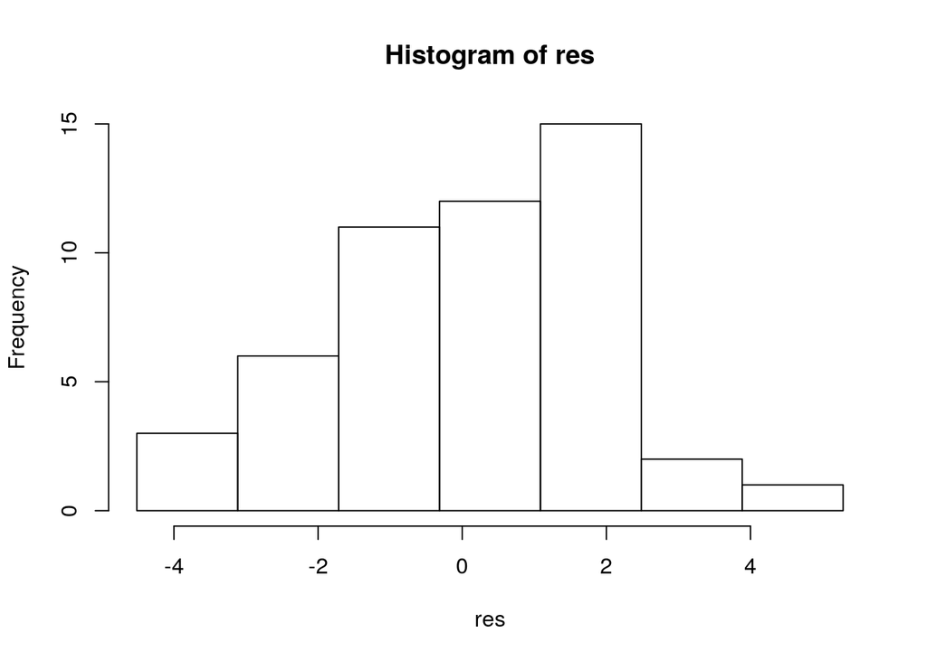

```r
brk<-seq(min(res), max(res) + h, by=h)
hist(res,breaks=brk)
```

Проверка гипотезы нормальности ошибок на уровне $\alpha$ по $\chi^2$

```r
l.b<-length(brk)
brk[1]<- -Inf
brk[l.b]<-Inf
#r = length(breaks) - 1
hh<-hist(res,breaks=brk,plot=FALSE)
nu<-hh$counts
breaks = hh$breaks;
r = length(breaks) - 1

l.b<-length(brk)
csq0<-function(s){
  if (s>0){
    p<-pnorm(brk[2:l.b],0,s)-pnorm(brk[1:(l.b-1)],0,s)
    return(sum((nu-n*p)^2/n/p))
  } else {
    return(Inf)
  }
}
csq.s<-nlm(csq0,p=sqrt(s2))$minimum
pv<-pchisq(csq.s,r-3,lower.tail=FALSE)
```

Результат: FALSE

Оценка расстояния до нормального рапределения по Колмагорову

```r
kolm.stat<-function(s){
  sres<-sort(res)
  fdistr<-pnorm(sres,0,s)
  max(abs(c(0:(n-1))/n-fdistr),abs(c(1:n)/n-fdistr))
}
ks.dist<-nlm(kolm.stat,p=sqrt(s2))$minimum


x2<-c(0:1000)*(max(res)-min(res))/1000+min(res)
y2<-pnorm(x2,0,nlm(kolm.stat,p=sqrt(s2))$estimate)
```

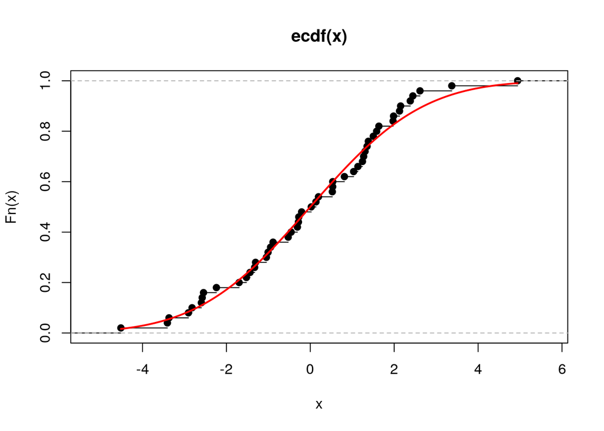

Полученое расстояние: 0.0677388

## 7

Построим ДИ для параметров

```r
C<-diag(c(1,1,1))
ph<-bht #t(C)%*%bhat
V<-diag(S1) # diag(C%*%S1%*%t(C))
xa<-qt(1-al/2,n-2)
s1<-sqrt(s2)
d<-xa*s1*sqrt(V)
CI<-data.frame(lw=ph-d,up=ph+d)
```

Полученые интервалы:

```
##           lw        up
## 1  3.4410260 6.0647164
## 2  0.1622953 3.5408451
## 3 -0.8533866 0.0979088
```

Доверительный эллипсоид имеет форму

$A\alpha=\{x,y:((xyz)^T-\beta)^T*(XX^T)^{-1}*((xyz)^T-\beta)\le 1\}$  
Где:  
$\beta=$

```
##            [,1]
## [1,]  4.7528712
## [2,]  1.8515702
## [3,] -0.3777389
```

```
##             [,1]       [,2]        [,3]
## [1,]  0.25594437 -0.3001346  0.07447286
## [2,] -0.30013459  0.4244056 -0.11552266
## [3,]  0.07447286 -0.1155227  0.03364738
```

## 8

Гипотеза линейной регрессионной зависимости Y от X: $H0: \beta3=0$  
Критерий:  
$\Phi(x)=\begin{cases} 0, \alpha<PV \\ 1,\alpha>PV \end{cases}$

Найдем статистику F-критерия и P-значение:

```r
FST<-bht[3]^2/S1[2,2]/s2
pv.f<-pf(FST,1,n-2,lower.tail=FALSE)
```

Получим 0.0844295 и 0.7726338  
Результат: TRUE